# Python_1 slides

#### Tuples

A tuple is an (immutable) ordered list of values. Python refers to values that cannot change as immutable, and an immutable list is called a tuple.

```python
dimensions = 800, 600
print(dimensions[0])
print(dimensions[1])

squares = (x**2 for x in range(10))
squares
```

```
800
600
```

```
<generator object <genexpr> at 0x7ffabc4bf200>
```

Note that comma creates a tuple not parantheses. Always use parantheses to increase readability.

```python
dimensions = 800, 600
print(dimensions[0])
print(dimensions[1])
```

```python
# Try this (uncomment)
# dimensions[0] = 1000  # this will return error
```

A tuple is in many ways similar to a list; one of the most important differences is that tuples can be used as keys in dictionaries and as elements of sets, while lists cannot. Here is a trivial example:

```python
d = {(x, x + 1): x for x in range(10)}  # Create a dictionary with tuple keys
t = (5, 6)       # Create a tuple
print(type(t))
print(d[t])
print(d[(1, 2)])
```

Any sequence (list, tuple, set) can be *unpacked* into individual variables.

```python
x, *rest = 1, 3, 4
print(x, rest)
```

```
1 [3, 4]
```

```python
x, y, z = [1, 2, 3] # Lists can be used for Multiple assignment
print(x, y, z)
```

```python
x, y, *rest = range(10) # Lists can be used for Multiple assignment
x, y, rest
```

```python
x, y, z = 1, 2, 3  # Tuples can be used for Multiple assignment
print(x, y, z)
```

### Flow Control

```python
fruits = ["apple", "banana", "cherry"]
for x in fruits:
  print(x)
```

```python
for x in "banana": # string is also a sequence type
  print(x)
```

```python
fruits = ["apple", "banana", "cherry"]
for x in fruits:
  if x == "banana":
    break
  print(x)
```

```python
fruits = ["apple", "banana", "cherry"]
for x in fruits:
  if x == "banana":
    continue
  print(x)
```

```python
# Shows while loop. Do not use this style though, prefer for loop.
# This style is considered not Pythonic
# https://peps.python.org/pep-0008/
idx = 0
while (idx < len(fruits)):
  print(fruits[idx])
  idx += 1
```

```python
age = 19
if age >= 18:
  print("You are old enough to vote!")
elif (age <= 27):
  pass
else:
  print("Sorry, you are too young to vote.")
```

```python
age = 12
if age < 4:
  price = 0
elif age < 18:
  price = 25
else:
  price = 40

print(f"Your admission cost is ${price}.")
```

### Differences from C

There is no `do {} while()` in Python.

#### Truth value testing

Any objects can be tested for truth value in `if` and `while` statements. Most objects are considered true, except the following ones which are considered false:

- constants defined to be false: None and False.
- zero of any numeric type: 0, 0.0, 0j, Decimal(0), Fraction(0, 1)
- empty sequences and collections: '', (), [], {}, set(), range(0)

### Functions

Python functions are defined using the `def` keyword. For example:

```python
# Making the argument b and c optional with 4 and 8 as default values
def sum2(a, b=4, c=8):
  return a + b + c, a*b*c # Returns a tuple of two values
```

```python
sum2(1, c=5)
```

```
(10, 20)
```

```python
sum_, prod_ = sum2(1, c=5) # Unpacking a tuple
```

```python
prod_
```

```
20
```

```python
def sign(x, y=100):
  if x > 0:
    return 'positive', 123
  elif x < 0:
    return 'negative', 123
  else:
    return 'zero', 123

for x in [-1, 0, 1]:
  v1, _ = sign(x)
  print(v1)
```

We will often define functions to take [optional keyword](https://docs.python.org/3/glossary.html#term-keyword-argument) arguments, like this:

```python
def hello(name, loud=False):
    if loud:
        print('HELLO, {}'.format(name.upper()))
    else:
        print('Hello, {}!'.format(name))

hello('Bob')
hello('Fred', loud=True)
```

Modifing a list in a function

When you pass a list to a function, the function can modify the list.

```python
def fun(list_):
  list_.append('new item')

a = [1, 2, 3]
fun(a)
print(a)
```

If you want to prevent a function from modifying a list, you can send a copy of a list to the function

```python
def fun(lst):
  lst.append('new item')

a = [1, 2, 3]
# Preventing a Function from Modifying a List
fun(a[:]) # The slice notation [:] makes a copy of the list
# fun(a.copy())
print(a)
```

**In-class Excercises 8**

### Variable Scope

The LEGB scope lookup rule. When a variable is referenced, Python searches for it in this order: in the local scope, in any enclosing functions’ local scopes, in the global scope, and finally in the built-in scope. The first occurrence wins. The place in your code where a variable is assigned usually determines its scope. In Python 3, nonlocal declarations can also force names to be mapped to enclosing function scopes, whether assigned or not.

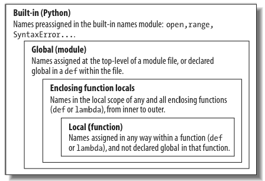

```python
# Global Namespaces
# Global scope
X = 99 # X and func assigned in module: global
#print(globals())

def func(Y): # Y and Z assigned in function: locals
  # Local scope
  X = 3
  Z = 0
  def funcfunc(Y2):
      if True:
          nonlocal Z
          Z = X + Y2 # X is a global
          for i in range(10):
                if True:
                    W = 0
      print("funcfunc", locals())
      return Z
  funcfunc(Y)
  print("func", locals())
  return Z

func(1) # func in module: result=100
```

```
funcfunc {'Y2': 1, 'i': 9, 'W': 0, 'X': 3, 'Z': 4}
func {'Y': 1, 'funcfunc': <function func.<locals>.funcfunc at 0x7ffabc4229d0>, 'X': 3, 'Z': 4}
```

```
4
```

```python
X = 99 # Global scope name: not used

def f1():
  X = 88 # Enclosing def local
  def f2():
    print(X) # Reference made in nested def
  f2()

f1() # Prints 88: enclosing def local
print(X)
```

```python
X = 99 # Global X

def func():
  X = 88 # Local X: hides global

func()
print(X) # Prints Global X 99: unchanged
```

The assignment within the function creates a local X that is a completely different variable from the global X in the module outside the function.

```python
X = 99 # Global X

def func():
  global X
  X = 88 # Local X: overrides global

func()
print(X) # Prints 88: unchanged
```

```python
def func():
    for x in range(100):
        pass

# what is x
x = 1
def func(x, y=[1, 2, 3]):
    y.append(4)
    print(y)

func(1)
func(1)
func(1)
```

```
[1, 2, 3, 4]
[1, 2, 3, 4, 4]
[1, 2, 3, 4, 4, 4]
```

```python
x = 0
for i in range(100):
    if i % 23 == 0:
        x = 23
    else:
        x = 1
# what is x?
x
```

```python
x = 0
def foo():
    for i in range(100):
        if i % 23 == 0:
            x = 23
        else:
            x = 1
# what is x?
x
```

### Exercise : Implement a sqrt function

As a way to play with functions and loops, let’s implement a square root function: given a number x, we want to find the number z for which z² is most nearly x.

Computers typically compute the square root of x using a loop. Starting with some guess z, we can adjust z based on how close z² is to x, producing a better guess: $z' = z - (z^2 - x) / (2z) $

Repeating this adjustment makes the guess better and better until we reach an answer that is as close to the actual square root as can be.

(Note: If you are interested in the details of the algorithm, the z² − x above is how far away z² is from where it needs to be (x), and the division by 2z is the derivative of z², to scale how much we adjust z by how quickly z² is changing. This general approach is called Newton’s method. It works well for many functions but especially well for square root. Newton’s methods is particular form of gradient descent.)

```python
x = 2; z = sqrt(x)
assert abs(z*z - x) < 1e-8
x = 3; z = sqrt(x)
assert abs(z*z - x) < 1e-8
x = 4; z = sqrt(x)
assert abs(z*z - x) < 1e-8
import random
for _ in range(10):
    x = random.randint(1, 100); z = sqrt(x)
    assert abs(z*z - x) < 1e-6
'success'
```

### Asterisks in Python

```python
3 * 5
```

```python
3 ** 5
```

```python
# Using * to unpack iterables into a list/tuple
numbers = [2, 1, 3, 4, 7]
more_numbers = [*numbers, 11, 18]
print(*more_numbers, sep=', ')

first, *rest = [*numbers, 11, 18]
print(rest, sep=', ')
```

```python
# Unpack a dictionary
date_info = {'ye ar': "2020", 'month': "01", 'day': "01"}
filename = "{ye ar}-{month}-{day}.txt".format(**date_info)
print(filename)

def func(**kwargs):
     return "{ye ar}-{month}-{day}.txt".format(**kwargs)
func(**date_info)
```

```
2020-01-01.txt
```

```
'2020-01-01.txt'
```

### zip

The zip() function takes iterables (can be zero or more), aggregates them in a tuple, and returns it.

```python
languages = ['Java', 'Python', 'JavaScript']
versions = [14, 3, 6]

result = list(zip(languages, versions))
print(result)
```

`zip` is almost the inverse of itself. It result in the same lists that you started with.

```python
list(zip(*result))
```

```python
mat = [[1, 2, 3],
        [4, 5, 6]]
mat_transpose = list(zip(*mat))
print(mat_transpose)
print(list(zip(*mat_transpose)))
```

```python
for (x, y) in zip(languages, versions): # pairs of items pulled from  two lists
  print(x, y)
```

```python
keys = ['spam', 'eggs', 'toast']
vals = [1, 3, 5]

D2 = {}
for (k, v) in zip(keys, vals):
  D2[k] = v

D2
```

zip function is more general than this example suggests. For instance, it accepts any type of sequence (really, any iterable object, including files), and it accepts more than two arguments. With three arguments, as in the following example, it builds a list of three-item tuples with items from each sequence, essentially projecting by columns (technically, we get an N-ary tuple for N arguments):

```python
T1, T2, T3 = (1,2,3), (4,5,6), (7,8,9)
list(zip(T1, T2, T3))
```

The * operator can be used in conjunction with zip() to unzip the list.

```python
coordinate = ['x', 'y', 'z']
value = [3, 4, 5]

result = zip(coordinate, value)
result_list = list(result)
print(result_list)

c, v =  zip(*result_list)
print('c =', c)
print('v =', v)
```

### Classes

#### Defining a Class

The syntax for defining classes in Python is :

```python
class Date:
    default_year = 1000
    def __init__(self, year, month, day):
        self.year = year
        self.month = month
        self.day = day

    def days(self):
        return (self.year  -2000)* 360 + self.month * 30 + self.day


today = Date(2023, 1, 26)
print(today.days())

class Addition:
    # first = 0
    # second = 0
    answer = 0 # Class member

    # parameterized constructor
    def __init__(self, first, second):
        self.first = first
        self.second = second

    def display(self):
        print("First number = " + str(self.first))
        print("Second number = " + str(self.second))
        print("Addition of two numbers = " + str(self.answer))

    def calculate(self):
        self.answer = self.first + self.second

# creating object of the class
# this will invoke parameterized constructor
obj = Addition(1000, 2000)

# perform Addition
obj.calculate()

# display result
obj.display()
```

[output not shown]

```python
class Person:

    # Constructor
    def __init__(self, name):
        self.name = name  # Create an instance variable

    # Instance method
    def getName(self):
        return self.name

    # To check if this person is an employee
    def isEmployee(self):
        return False

# Making an instance from a class
g = Person('Fred')  # Construct an instance of the Greeter class

# Accessing attributes
print(g.name)

# Calling methods
print(g.getName())
```

- The **self** parameter is required in the method definition, and it must come first before the other parameters. It must be included in the definition because when Python calls this method later (to create an instance), the method call will automatically pass the self argument.
- Every method call associated with an instance automatically passes **self**, which is a reference to the instance itself; it gives the individual instance access to the attributes and methods in the class.

In a class, the implicit behavior of passing the object as the first argument is avoided if a method is declared as static, as shown in the following example.

```python
class A(object):

    @staticmethod
    def stat_meth():
        print("Look no self was passed")

a = A()
a.stat_meth()
```

#### Inheritance

Inheritance is the capability of one class to derive or inherit the properties from another class. The benefits of inheritance are:

- It represents real-world relationships well.
- It provides reusability of a code. We don’t have to write the same code again and again. Also, it allows us to add more features to a class without modifying it.
- It is transitive in nature, which means that if class B inherits from another class A, then all the subclasses of B would automatically inherit from class A.

```python
# Inherited or Subclass (Note Person in bracket)
class Employee(Person):

    # Constructor
    def __init__(self, name, year):
        self.years = year  # Create an instance variable
        super().__init__(name)

    # Overriding Methods from the Parent Class
    def isEmployee(self):
        return True

# Driver code
emp = Person("Geek1")  # An Object of Person
print(emp.getName(), emp.isEmployee())

emp = Employee("Geek2", 20) # An Object of Employee
print(emp.getName(), emp.isEmployee())
```

### Iterators

#### An iterator is an object that can be iterated upon, meaning that you can traverse through all the values.

```python
mytuple = ("apple", "banana", "cherry")
myit = iter(mytuple) # define

print(next(myit)) # apple
print(next(myit)) # banana
print(next(myit)) # cherry
# Try this (uncomment)
# print(next(myit)) # raises StopIteration exception (not all exceptions are errors)
```

#### Strings, lists, tuples, dictionaries, and sets are all iterable objects.

```python
mystr = "banana"
myit = iter(mystr)

print(next(myit))
print(next(myit))
print(next(myit))
print(next(myit))
print(next(myit))
print(next(myit))
```

#### Looping Through an Iterator

C-style approach

```python
mytuple = ("apple", "banana", "cherry")
i = 0
while (i < len(mytuple)):
    print(mytuple[i])
    i += 1
```

A better approach

```python
mytuple = ("apple", "banana", "cherry")

print(mytuple)

for idx, val in enumerate(mytuple):
  print(idx, val)
```

```python
mytuple = ("apple", "banana", "cherry")

print(mytuple)

for val in mytuple:
  print(val)
```

```python
mystr = "banana"

for x in mystr:
  print(x)
```

```python
# Iterating over dictionary
d = dict()
d['xyz'] = 123
d['abc'] = 345
for i in d :
    # print("%s  %d" %(i, d[i]))
    print("{}\t{}".format(i, d[i]))
```

#### Create an Iterator

To create an object/class as an iterator, you have to implement the methods __iter__() and __next__() to your object.

- **__iter__** method that is called on initialization of an iterator. This should return an object that has a __next__ method.
- **__next__** should return the next value for the iterable. This method should raise a **StopIteration** to signal the end of the iteration.

```python
class MyNumbers:
  def __iter__(self):
    self.a = 1
    return self

  def __next__(self):
    x = self.a
    self.a += 1
    return x

myinstance = MyNumbers()
myiter = iter(myinstance)

print(next(myiter))
print(next(myiter))
print(next(myiter))
print(next(myiter))
print(next(myiter))
```

Stop after 10 iterations by raising the StopIteration exception

```python
class MyNumbers:
  def __iter__(self):
    self.a = 1
    return self

  def __next__(self):
    if self.a <= 10:
      x = self.a
      self.a += 1
      return x
    else:
      raise StopIteration

myclass = MyNumbers()
myiter = iter(myclass)

for x in myiter:
  print(x)
```

#### zip function

Combine mulitple iterator

```python
# Two separate lists
thing = ["Apple", "Audi", "Pasta", "dog", "UMAINE"]
category = ["fruit", "car",  "food", "animal"]

# Combining lists and printing
for t, c in zip(thing, category):
    print("{} is {}".format(t, c))
```

Use "*" operator to unzip

```python
l1,l2 = zip(*[('Apple', 'fruit'),
              ('Audi', 'car'),
              ('Pasta', 'food')
           ])

# Printing unzipped lists
print(l1)
print(l2)
```